# **Introduction**

Participants :

- **Aboubacar Ouattara**
- **Alfred Sourou SODJI**
- **Ange-Marie GOUNADON**
- **Modibo TRAORE**

Afin d'assurer une compréhension approfondie de nos données, nous avons initialement effectué un nettoyage des données et du feature engineering. Pendant cette étape, nous avons réalisé une analyse de la cardinalité et une analyse descriptive à l'aide de graphiques variés et de méthodes statistiques. Cette phase de travail nous a permis de justifier l'importance de chaque variable de notre ensemble de données et, finalement, de sélectionner celles que nous utiliserons pour la prédiction.

Suite à cette étape de feature engineering, nous avons entrepris la phase de tests de différents modèles sur notre ensemble de données. Étant donné que la plupart de nos variables sont catégorielles, nous avons utilisé des techniques d'encodage, notamment le OneHotEncoder pour la régression logistique et le LabelEncoder pour les autres modèles. Le déséquilibre observé dans les données a également fait l'objet d'une analyse approfondie. Dans un premier temps, nous avons élaboré des modèles sur l'ensemble de la base de données, que nous avons comparés à des modèles élaborés sur des données d'entraînement rééquilibrées. La méthode de rééquilibrage choisie est le sous-échantillonnage, étant donné le nombre important d'observations dans notre base de données.

Nous avons implémenté les modèles de prédictions suivants : la régression logistique, la forêt aléatoire, le gradient boosting et le KNN. Chaque modèle a été testé avec différents ensembles de covariables, ce qui a donné lieu à un nombre significatif de tests. La métrique prise en compte pour la comparaison des modèles est le recall, étant donné que l'objectif principal de est de minimiser les erreurs de prédiction des enchères émises par les robots. Le meilleur modèle sera donc sélectionné en fonction de sa performance sur le recall.

# **Analyse Exploratoire des Données**

```python
import pandas as pd
import seaborn as sns
import matplotlib.pyplot as plt
```

```python
from scipy.stats import chi2_contingency
```

Commençons d'abord à importer les bases de données fournir pour ce projet

```python
from google.colab import drive
drive.mount('/content/drive')
```

```python
bids_data = pd.read_csv("C:/Users/pc/Downloads/Projet/bids.csv")
```

```python
train_data = pd.read_csv("C:/Users/pc/Downloads/Projet/train.csv")
```

```python
test_data = pd.read_csv("/content/drive/MyDrive/Données_Devoir_ML/test.csv")
```

Aperçu et interprétation des data

```python
@title bids.csv
bids_data
```

|  | bid_id | bidder_id | auction | merchandise | device | time | country | ip | url |
| --- | --- | --- | --- | --- | --- | --- | --- | --- | --- |
| 0 | 0 | 8dac2b259fd1c6d1120e519fb1ac14fbqvax8 | ewmzr | jewelry | phone0 | 9759243157894736 | us | 69.166.231.58 | vasstdc27m7nks3 |
| 1 | 1 | 668d393e858e8126275433046bbd35c6tywop | aeqok | furniture | phone1 | 9759243157894736 | in | 50.201.125.84 | jmqlhflrzwuay9c |
| 2 | 2 | aa5f360084278b35d746fa6af3a7a1a5ra3xe | wa00e | home goods | phone2 | 9759243157894736 | py | 112.54.208.157 | vasstdc27m7nks3 |
| 3 | 3 | 3939ac3ef7d472a59a9c5f893dd3e39fh9ofi | jefix | jewelry | phone4 | 9759243157894736 | in | 18.99.175.133 | vasstdc27m7nks3 |
| 4 | 4 | 8393c48eaf4b8fa96886edc7cf27b372dsibi | jefix | jewelry | phone5 | 9759243157894736 | in | 145.138.5.37 | vasstdc27m7nks3 |
| ... | ... | ... | ... | ... | ... | ... | ... | ... | ... |
| 7656329 | 7656329 | 626159dd6f2228ede002d9f9340f75b7puk8d | 3e64w | jewelry | phone91 | 9709222052631578 | ru | 140.204.227.63 | cghhmomsaxi6pug |
| 7656330 | 7656330 | a318ea333ceee1ba39a494476386136a826dv | xn0y0 | mobile | phone236 | 9709222052631578 | pl | 24.232.159.118 | wgggpdg2gx5pesn |
| 7656331 | 7656331 | f5b2bbad20d1d7ded3ed960393bec0f40u6hn | gja6c | sporting goods | phone80 | 9709222052631578 | za | 80.237.28.246 | 5xgysg14grlersa |
| 7656332 | 7656332 | d4bd412590f5106b9d887a43c51b254eldo4f | hmwk8 | jewelry | phone349 | 9709222052631578 | my | 91.162.27.152 | bhtrek44bzi2wfl |
| 7656333 | 7656333 | 0ea62aaa9c3ffcc6db584cb69c1f6c4bcripp | c9ox9 | mobile | phone82 | 9709222052631578 | jo | 160.243.101.60 | vasstdc27m7nks3 |

7656334 rows × 9 columns

```python
bids_data.info()
```

```
<class 'pandas.core.frame.DataFrame'>
RangeIndex: 7656334 entries, 0 to 7656333
Data columns (total 9 columns):
 #   Column       Dtype
---  ------       -----
 0   bid_id       int64
 1   bidder_id    object
 2   auction      object
 3   merchandise  object
 4   device       object
 5   time         int64
 6   country      object
 7   ip           object
 8   url          object
dtypes: int64(2), object(7)
memory usage: 525.7+ MB
```

```python
@title train.csv
train_data
```

|  | bidder_id | payment_account | address | outcome |
| --- | --- | --- | --- | --- |
| 0 | 91a3c57b13234af24875c56fb7e2b2f4rb56a | a3d2de7675556553a5f08e4c88d2c228754av | a3d2de7675556553a5f08e4c88d2c228vt0u4 | 0.0 |
| 1 | 624f258b49e77713fc34034560f93fb3hu3jo | a3d2de7675556553a5f08e4c88d2c228v1sga | ae87054e5a97a8f840a3991d12611fdcrfbq3 | 0.0 |
| 2 | 1c5f4fc669099bfbfac515cd26997bd12ruaj | a3d2de7675556553a5f08e4c88d2c2280cybl | 92520288b50f03907041887884ba49c0cl0pd | 0.0 |
| 3 | 4bee9aba2abda51bf43d639013d6efe12iycd | 51d80e233f7b6a7dfdee484a3c120f3b2ita8 | 4cb9717c8ad7e88a9a284989dd79b98dbevyi | 0.0 |
| 4 | 4ab12bc61c82ddd9c2d65e60555808acqgos1 | a3d2de7675556553a5f08e4c88d2c22857ddh | 2a96c3ce94b3be921e0296097b88b56a7x1ji | 0.0 |
| ... | ... | ... | ... | ... |
| 2008 | 369515b3af4f8ca582f90271d30b14b6r52aw | a1f85275793c4a782f0a668711f41b927ivc9 | e6882cf204a9482edd042b6e31791dfctxzx8 | 0.0 |
| 2009 | f939c17ffc7c39ac9b35b69e5e75179fv9pe2 | a3d2de7675556553a5f08e4c88d2c2286s1m2 | b9b03d5a127eb07aeb9163cdcf524e1344ac9 | 0.0 |
| 2010 | c806dbb2decba0ed3c4ff5e2e60a74c2wjvbl | a3d2de7675556553a5f08e4c88d2c22856leq | d02c2b288b8aabd79ff47118aff41a2dqwzwc | 0.0 |
| 2011 | 0381a69b7a061e9ace2798fd48f1f537mgq57 | fd87037ce0304077079c749f420f0b4c54uo0 | f030a221726fbcdfc4dc7dfd1b381a112hieq | 0.0 |
| 2012 | 84a769adc98498f52debfe57b93a0789556f4 | fbe0ce34d6546ebd9e4c63afc68b085byd2tf | a3d2de7675556553a5f08e4c88d2c228fib6p | 0.0 |

2013 rows × 4 columns

```python
train_data.info()
```

```
<class 'pandas.core.frame.DataFrame'>
RangeIndex: 2013 entries, 0 to 2012
Data columns (total 4 columns):
 #   Column           Non-Null Count  Dtype
---  ------           --------------  -----
 0   bidder_id        2013 non-null   object
 1   payment_account  2013 non-null   object
 2   address          2013 non-null   object
 3   outcome          2013 non-null   float64
dtypes: float64(1), object(3)
memory usage: 63.0+ KB
```

```python
print(train_data["outcome"].unique())
```

```
[0. 1.]
```

- La data train contient 2013 observations et 4 variables. Toutes ces variables sont catégorielles. Elle ne contient pas de valeurs NULL
- Elle à la colonne **bidder_id** qui se retrouve aussi dans la data **bids**. Cette colonne va donc nous permettre de fusionner les deux bases de données pour une analyse approfondie

```python
@title test.csv
test_data
```

|  | ID_code | var_0 | var_1 | var_2 | var_3 | var_4 | var_5 | var_6 | var_7 | var_8 | ... | var_190 | var_191 | var_192 | var_193 | var_194 | var_195 | var_196 | var_197 | var_198 | var_199 |
| --- | --- | --- | --- | --- | --- | --- | --- | --- | --- | --- | --- | --- | --- | --- | --- | --- | --- | --- | --- | --- | --- |
| 0 | test_0 | 11.0656 | 7.7798 | 12.9536 | 9.4292 | 11.4327 | -2.3805 | 5.8493 | 18.2675 | 2.1337 | ... | -2.1556 | 11.8495 | -1.4300 | 2.4508 | 13.7112 | 2.4669 | 4.3654 | 10.7200 | 15.4722 | -8.7197 |
| 1 | test_1 | 8.5304 | 1.2543 | 11.3047 | 5.1858 | 9.1974 | -4.0117 | 6.0196 | 18.6316 | -4.4131 | ... | 10.6165 | 8.8349 | 0.9403 | 10.1282 | 15.5765 | 0.4773 | -1.4852 | 9.8714 | 19.1293 | -20.9760 |
| 2 | test_2 | 5.4827 | -10.3581 | 10.1407 | 7.0479 | 10.2628 | 9.8052 | 4.8950 | 20.2537 | 1.5233 | ... | -0.7484 | 10.9935 | 1.9803 | 2.1800 | 12.9813 | 2.1281 | -7.1086 | 7.0618 | 19.8956 | -23.1794 |
| 3 | test_3 | 8.5374 | -1.3222 | 12.0220 | 6.5749 | 8.8458 | 3.1744 | 4.9397 | 20.5660 | 3.3755 | ... | 9.5702 | 9.0766 | 1.6580 | 3.5813 | 15.1874 | 3.1656 | 3.9567 | 9.2295 | 13.0168 | -4.2108 |
| 4 | test_4 | 11.7058 | -0.1327 | 14.1295 | 7.7506 | 9.1035 | -8.5848 | 6.8595 | 10.6048 | 2.9890 | ... | 4.2259 | 9.1723 | 1.2835 | 3.3778 | 19.5542 | -0.2860 | -5.1612 | 7.2882 | 13.9260 | -9.1846 |
| ... | ... | ... | ... | ... | ... | ... | ... | ... | ... | ... | ... | ... | ... | ... | ... | ... | ... | ... | ... | ... | ... |
| 199995 | test_199995 | 13.1678 | 1.0136 | 10.4333 | 6.7997 | 8.5974 | -4.1641 | 4.8579 | 14.7625 | -2.7239 | ... | 2.0544 | 9.6849 | 4.6734 | -1.3660 | 12.8721 | 1.2013 | -4.6195 | 9.1568 | 18.2102 | 4.8801 |
| 199996 | test_199996 | 9.7171 | -9.1462 | 7.3443 | 9.1421 | 12.8936 | 3.0191 | 5.6888 | 18.8862 | 5.0915 | ... | 5.0071 | 6.6548 | 1.8197 | 2.4104 | 18.9037 | -0.9337 | 2.9995 | 9.1112 | 18.1740 | -20.7689 |
| 199997 | test_199997 | 11.6360 | 2.2769 | 11.2074 | 7.7649 | 12.6796 | 11.3224 | 5.3883 | 18.3794 | 1.6603 | ... | 5.1536 | 2.6498 | 2.4937 | -0.0637 | 20.0609 | -1.1742 | -4.1524 | 9.1933 | 11.7905 | -22.2762 |
| 199998 | test_199998 | 13.5745 | -0.5134 | 13.6584 | 7.4855 | 11.2241 | -11.3037 | 4.1959 | 16.8280 | 5.3208 | ... | 3.4259 | 8.5012 | 2.2713 | 5.7621 | 17.0056 | 1.1763 | -2.3761 | 8.1079 | 8.7735 | -0.2122 |
| 199999 | test_199999 | 10.4664 | 1.8070 | 10.2277 | 6.0654 | 10.0258 | 1.0789 | 4.8879 | 14.4892 | -0.5902 | ... | 0.1398 | 9.2828 | 1.3601 | 4.8985 | 20.0926 | -1.3048 | -2.5981 | 10.3378 | 14.3340 | -7.7094 |

200000 rows × 201 columns

```python
test_data.describe()
```

|  | var_0 | var_1 | var_2 | var_3 | var_4 | var_5 | var_6 | var_7 | var_8 | var_9 | ... | var_190 | var_191 | var_192 | var_193 | var_194 | var_195 | var_196 | var_197 | var_198 | var_199 |
| --- | --- | --- | --- | --- | --- | --- | --- | --- | --- | --- | --- | --- | --- | --- | --- | --- | --- | --- | --- | --- | --- |
| count | 200000.000000 | 200000.000000 | 200000.000000 | 200000.000000 | 200000.000000 | 200000.000000 | 200000.000000 | 200000.000000 | 200000.000000 | 200000.000000 | ... | 200000.000000 | 200000.000000 | 200000.000000 | 200000.000000 | 200000.000000 | 200000.000000 | 200000.000000 | 200000.000000 | 200000.000000 | 200000.000000 |
| mean | 10.658737 | -1.624244 | 10.707452 | 6.788214 | 11.076399 | -5.050558 | 5.415164 | 16.529143 | 0.277135 | 7.569407 | ... | 3.189766 | 7.458269 | 1.925944 | 3.322016 | 17.996967 | -0.133657 | 2.290899 | 8.912428 | 15.869184 | -3.246342 |
| std | 3.036716 | 4.040509 | 2.633888 | 2.052724 | 1.616456 | 7.869293 | 0.864686 | 3.424482 | 3.333375 | 1.231865 | ... | 4.551239 | 3.025189 | 1.479966 | 3.995599 | 3.140652 | 1.429678 | 5.446346 | 0.920904 | 3.008717 | 10.398589 |
| min | 0.188700 | -15.043400 | 2.355200 | -0.022400 | 5.484400 | -27.767000 | 2.216400 | 5.713700 | -9.956000 | 4.243300 | ... | -14.093300 | -2.407000 | -3.340900 | -11.413100 | 9.382800 | -4.911900 | -13.944200 | 6.169600 | 6.584000 | -39.457800 |
| 25% | 8.442975 | -4.700125 | 8.735600 | 5.230500 | 9.891075 | -11.201400 | 4.772600 | 13.933900 | -2.303900 | 6.623800 | ... | -0.095000 | 5.166500 | 0.882975 | 0.587600 | 15.634775 | -1.160700 | -1.948600 | 8.260075 | 13.847275 | -11.124000 |
| 50% | 10.513800 | -1.590500 | 10.560700 | 6.822350 | 11.099750 | -4.834100 | 5.391600 | 16.422700 | 0.372000 | 7.632000 | ... | 3.162400 | 7.379000 | 1.892600 | 3.428500 | 17.977600 | -0.162000 | 2.403600 | 8.892800 | 15.943400 | -2.725950 |
| 75% | 12.739600 | 1.343400 | 12.495025 | 8.327600 | 12.253400 | 0.942575 | 6.005800 | 19.094550 | 2.930025 | 8.584825 | ... | 6.336475 | 9.531100 | 2.956000 | 6.174200 | 20.391725 | 0.837900 | 6.519800 | 9.595900 | 18.045200 | 4.935400 |
| max | 22.323400 | 9.385100 | 18.714100 | 13.142000 | 16.037100 | 17.253700 | 8.302500 | 28.292800 | 9.665500 | 11.003600 | ... | 20.359000 | 16.716500 | 8.005000 | 17.632600 | 27.947800 | 4.545400 | 15.920700 | 12.275800 | 26.538400 | 27.907400 |

8 rows × 200 columns

- La base de donnée **test** n'a théoriquement aucun lien avec les deux précédentes et elle contient 201 colonnes dont 200 sont numériques à l'exception de la colonne **ID_code** qui n'est numérique et ne s'identifie à aucune colonne des autres bases de données.

**Dans la suite, nous allons exploiter les bases de données bids et train**

Nous commençons maintement à faire une **jointure** des Dataframes *train_data* et *bid_data* sur la base des **bidder_id** qui sont communs au deux Dataframes.

```python
merge_data = pd.merge(train_data, bids_data, on='bidder_id', how='inner')
```

```python
merge_data
```

|  | bidder_id | payment_account | address | outcome | bid_id | auction | merchandise | device | time | country | ip | url |
| --- | --- | --- | --- | --- | --- | --- | --- | --- | --- | --- | --- | --- |
| 0 | 91a3c57b13234af24875c56fb7e2b2f4rb56a | a3d2de7675556553a5f08e4c88d2c228754av | a3d2de7675556553a5f08e4c88d2c228vt0u4 | 0.0 | 85371 | yitr4 | home goods | phone35 | 9759489368421052 | ke | 82.34.177.248 | vasstdc27m7nks3 |
| 1 | 91a3c57b13234af24875c56fb7e2b2f4rb56a | a3d2de7675556553a5f08e4c88d2c228754av | a3d2de7675556553a5f08e4c88d2c228vt0u4 | 0.0 | 274487 | btpyy | home goods | phone1004 | 9760248684210526 | zm | 202.130.71.167 | vasstdc27m7nks3 |
| 2 | 91a3c57b13234af24875c56fb7e2b2f4rb56a | a3d2de7675556553a5f08e4c88d2c228754av | a3d2de7675556553a5f08e4c88d2c228vt0u4 | 0.0 | 527436 | kj2ko | home goods | phone4 | 9762260578947368 | ke | 22.54.76.225 | vasstdc27m7nks3 |
| 3 | 91a3c57b13234af24875c56fb7e2b2f4rb56a | a3d2de7675556553a5f08e4c88d2c228754av | a3d2de7675556553a5f08e4c88d2c228vt0u4 | 0.0 | 554135 | 1m5t8 | home goods | phone4 | 9762430736842105 | ke | 32.13.237.126 | vasstdc27m7nks3 |
| 4 | 91a3c57b13234af24875c56fb7e2b2f4rb56a | a3d2de7675556553a5f08e4c88d2c228754av | a3d2de7675556553a5f08e4c88d2c228vt0u4 | 0.0 | 607628 | btpyy | home goods | phone4 | 9762789000000000 | ke | 202.236.188.240 | vasstdc27m7nks3 |
| ... | ... | ... | ... | ... | ... | ... | ... | ... | ... | ... | ... | ... |
| 3071219 | c806dbb2decba0ed3c4ff5e2e60a74c2wjvbl | a3d2de7675556553a5f08e4c88d2c22856leq | d02c2b288b8aabd79ff47118aff41a2dqwzwc | 0.0 | 609792 | jefix | mobile | phone316 | 9762802052631578 | id | 28.18.7.49 | ar89au37swuzvzz |
| 3071220 | c806dbb2decba0ed3c4ff5e2e60a74c2wjvbl | a3d2de7675556553a5f08e4c88d2c22856leq | d02c2b288b8aabd79ff47118aff41a2dqwzwc | 0.0 | 2297899 | jefix | mobile | phone33 | 9772600526315789 | id | 161.237.171.157 | ar89au37swuzvzz |
| 3071221 | 0381a69b7a061e9ace2798fd48f1f537mgq57 | fd87037ce0304077079c749f420f0b4c54uo0 | f030a221726fbcdfc4dc7dfd1b381a112hieq | 0.0 | 3400601 | jqx39 | office equipment | phone11 | 9636754421052631 | sa | 54.212.21.87 | cgb17jpn1ixq9hw |
| 3071222 | 84a769adc98498f52debfe57b93a0789556f4 | fbe0ce34d6546ebd9e4c63afc68b085byd2tf | a3d2de7675556553a5f08e4c88d2c228fib6p | 0.0 | 2007255 | ntjde | jewelry | phone59 | 9770756157894736 | ru | 79.72.96.0 | 9ov8hm82p20sxlz |
| 3071223 | 84a769adc98498f52debfe57b93a0789556f4 | fbe0ce34d6546ebd9e4c63afc68b085byd2tf | a3d2de7675556553a5f08e4c88d2c228fib6p | 0.0 | 2007533 | ntjde | jewelry | phone59 | 9770757947368421 | ru | 79.72.96.0 | 9ov8hm82p20sxlz |

3071224 rows × 12 columns

```python
merge_data.info()
```

```
<class 'pandas.core.frame.DataFrame'>
Int64Index: 3071224 entries, 0 to 3071223
Data columns (total 12 columns):
 #   Column           Dtype
---  ------           -----
 0   bidder_id        object
 1   payment_account  object
 2   address          object
 3   outcome          float64
 4   bid_id           int64
 5   auction          object
 6   merchandise      object
 7   device           object
 8   time             int64
 9   country          object
 10  ip               object
 11  url              object
dtypes: float64(1), int64(2), object(9)
memory usage: 304.6+ MB
```

Nous obtenons un Dataframe de 3071224 observations et 12 variables. On aurait pu s'attendre à avoir une Dataframe d'au plus 2013 observation. Cependant les **bidder_id** dans le Dataframe **bid_data** ne sont pas unique. Ce qui conduire à cette observation. En effet dans le Dataframe de jointure, il y à des **bidder_id** qui se repètent avec différentes informations dans les autres colonnes. Du point de vu métier, cela peut se comprendre comme le fait qu'un même client émet différentes enchères sur plusieurs produits.

L'analyse exploratoire qui suit portera donc sur la Dataframe obtenu après la fusion.

```python
merge_data = merge_data.drop_duplicates()
```

Le code ci-dessus nous permet de nous assurer formellement qu'aucune observation ne se repète

```python
merge_data
```

|  | bidder_id | payment_account | address | outcome | bid_id | auction | merchandise | device | time | country | ip | url |
| --- | --- | --- | --- | --- | --- | --- | --- | --- | --- | --- | --- | --- |
| 0 | 91a3c57b13234af24875c56fb7e2b2f4rb56a | a3d2de7675556553a5f08e4c88d2c228754av | a3d2de7675556553a5f08e4c88d2c228vt0u4 | 0.0 | 85371 | yitr4 | home goods | phone35 | 9759489368421052 | ke | 82.34.177.248 | vasstdc27m7nks3 |
| 1 | 91a3c57b13234af24875c56fb7e2b2f4rb56a | a3d2de7675556553a5f08e4c88d2c228754av | a3d2de7675556553a5f08e4c88d2c228vt0u4 | 0.0 | 274487 | btpyy | home goods | phone1004 | 9760248684210526 | zm | 202.130.71.167 | vasstdc27m7nks3 |
| 2 | 91a3c57b13234af24875c56fb7e2b2f4rb56a | a3d2de7675556553a5f08e4c88d2c228754av | a3d2de7675556553a5f08e4c88d2c228vt0u4 | 0.0 | 527436 | kj2ko | home goods | phone4 | 9762260578947368 | ke | 22.54.76.225 | vasstdc27m7nks3 |
| 3 | 91a3c57b13234af24875c56fb7e2b2f4rb56a | a3d2de7675556553a5f08e4c88d2c228754av | a3d2de7675556553a5f08e4c88d2c228vt0u4 | 0.0 | 554135 | 1m5t8 | home goods | phone4 | 9762430736842105 | ke | 32.13.237.126 | vasstdc27m7nks3 |
| 4 | 91a3c57b13234af24875c56fb7e2b2f4rb56a | a3d2de7675556553a5f08e4c88d2c228754av | a3d2de7675556553a5f08e4c88d2c228vt0u4 | 0.0 | 607628 | btpyy | home goods | phone4 | 9762789000000000 | ke | 202.236.188.240 | vasstdc27m7nks3 |
| ... | ... | ... | ... | ... | ... | ... | ... | ... | ... | ... | ... | ... |
| 3071219 | c806dbb2decba0ed3c4ff5e2e60a74c2wjvbl | a3d2de7675556553a5f08e4c88d2c22856leq | d02c2b288b8aabd79ff47118aff41a2dqwzwc | 0.0 | 609792 | jefix | mobile | phone316 | 9762802052631578 | id | 28.18.7.49 | ar89au37swuzvzz |
| 3071220 | c806dbb2decba0ed3c4ff5e2e60a74c2wjvbl | a3d2de7675556553a5f08e4c88d2c22856leq | d02c2b288b8aabd79ff47118aff41a2dqwzwc | 0.0 | 2297899 | jefix | mobile | phone33 | 9772600526315789 | id | 161.237.171.157 | ar89au37swuzvzz |
| 3071221 | 0381a69b7a061e9ace2798fd48f1f537mgq57 | fd87037ce0304077079c749f420f0b4c54uo0 | f030a221726fbcdfc4dc7dfd1b381a112hieq | 0.0 | 3400601 | jqx39 | office equipment | phone11 | 9636754421052631 | sa | 54.212.21.87 | cgb17jpn1ixq9hw |
| 3071222 | 84a769adc98498f52debfe57b93a0789556f4 | fbe0ce34d6546ebd9e4c63afc68b085byd2tf | a3d2de7675556553a5f08e4c88d2c228fib6p | 0.0 | 2007255 | ntjde | jewelry | phone59 | 9770756157894736 | ru | 79.72.96.0 | 9ov8hm82p20sxlz |
| 3071223 | 84a769adc98498f52debfe57b93a0789556f4 | fbe0ce34d6546ebd9e4c63afc68b085byd2tf | a3d2de7675556553a5f08e4c88d2c228fib6p | 0.0 | 2007533 | ntjde | jewelry | phone59 | 9770757947368421 | ru | 79.72.96.0 | 9ov8hm82p20sxlz |

3071224 rows × 12 columns

# Nettoyage de la donnée

```python
print(merge_data["merchandise"].unique())
print(f"="*70)
print(merge_data["device"].unique()[0:11])
print(f"="*70)
print(merge_data["time"].unique()[0:11])
```

```
['home goods' 'office equipment' 'sporting goods' 'books and music'
 'mobile' 'jewelry' 'computers' 'clothing' 'furniture' 'auto parts']
======================================================================
['phone35' 'phone1004' 'phone4' 'phone195' 'phone79' 'phone1309'
 'phone378' 'phone1048' 'phone317' 'phone19' 'phone5']
======================================================================
[9759489368421052 9760248684210526 9762260578947368 9762430736842105
 9762789000000000 9763163263157894 9763386105263157 9764266789473684
 9764391578947368 9764657789473684 9764741210526315]
```

Les merchandises sur lesquelles les enchères sont placées sont [*'home' goods' 'office equipment' 'sporting goods' 'books and music' 'mobile' 'jewelry' 'computers' 'clothing' 'furniture' 'auto parts'*] et on voit ques ces éléments sont bien compréhensibles. Pareil pour les observations de la **device**.

Cependant la vairiables **time** nous est incompréhensible.

```python
null_counts_merge_data = merge_data.isnull().sum()
```

```python
null_counts_merge_data
```

```
bidder_id             0
payment_account       0
address               0
outcome               0
bid_id                0
auction               0
merchandise           0
device                0
time                  0
country            2701
ip                    0
url                   0
dtype: int64
```

Nous remarquons que toutes les colonnes sont bien remplies à l'exception de la colonne **country** qui contient 2701 valeurs NULL. Cette colonne **country** fera l'objet d'un traitement approfondi.

Nous affichons le sous Dataframe des observations pour lesquelles la colonne **country** n'est pas renseignée pour ensuite observer la distribution de notre variable cible "**outcome**" sur cette dernière.

```python
# Créer un masque pour les lignes avec des valeurs nulles dans la colonne 'country'
mask_null_outcome = merge_data['country'].isnull()

# Obtenir la partie du DataFrame où 'outcome' est NULL
result_null_outcome = merge_data[mask_null_outcome]
print(result_null_outcome.shape)
```

```
(2701, 12)
```

```python
result_null_outcome['outcome'].value_counts()
```

```
0.0    2438
1.0     263
Name: outcome, dtype: int64
```

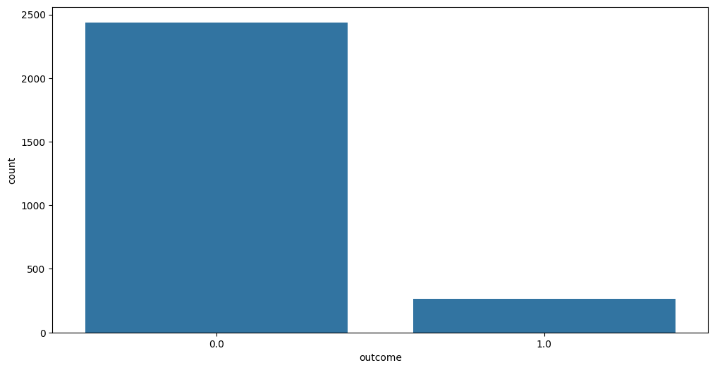

```python
# Afficher l'histogramme de la colonne 'outcome' avec seaborn
plt.figure(figsize=(12, 6))
sns.countplot(x='outcome', data=result_null_outcome)
```

Parmi les enchères pour lesquelles le pays n'est pas rempli, 2438 ne sont pas placées par des robot (outcome = 0) et les 263 autres sont placées par des robots.

Nous pouvons décider d'une stratégie de remplissage des données ou de supprimer les lignes correspondantes. Pour nous décider, observons la distribution de notre variable cible dans le Dataframe global **merge_data**

```python
#result_null_outcome
```

```python
merge_data["outcome"].value_counts()
```

```
0.0    2658808
1.0     412416
Name: outcome, dtype: int64
```

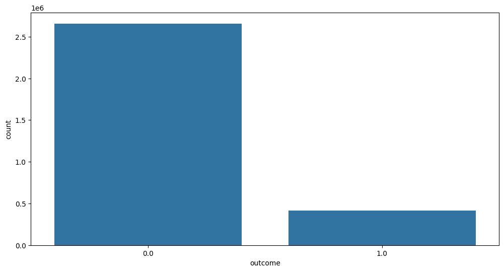

```python
# Afficher l'histogramme de la colonne 'outcome' avec seaborn
plt.figure(figsize=(12, 6))
sns.countplot(x='outcome', data=merge_data)
```

Dans le Dataframe **merge_data** nous avons 2658808 enchères qui ne sont pas placées par les robots (outcome = 0) et 412416 enchères placées par les robots (outcome = 1).

- Nous avons un déséquilibre entre le nombre d'enchères placées par les robot et le nombre d'enchères qui ne sont pas placé par les robots. La classe des enchères qui ne sont pas placées par des robots est majoritaire et de façon excessive.
- Ce déséquilibre des classes dans la base de donnée aura certainement un impact sur l'entrainement d'un modèle machine learning. En effet on peut rencontrer un souci de généralisation. Cela peut expliquer plus tard les performances de nos modèles.
- Avant de continuer sur ces aspects, revenons à la gestion des valeurs manquantes. Le déséquilibre observé précédemment et le caractère négligeable du nombre d'enchères qui ne sont pas placées par les robots et dont la colonne country n'est pas remplie par rapport au nombre total d'enchères qui ne sont pas placées par des robots, nous amène à supprimer les valeurs manquantes de cette catégorie.
- La classe des enchères placées par les robots étant en minorité, on pourrait penser à une méthode de remplissage de cette catégorie pour les valeurs manquantes de la colonne country. Par exemple, pour chaque ligne, on choisit le **bidder_id** et pour toutes les observations ayant le même **bidder_id** dont la cellule **country** n'est pas manquante, on cherche le pays qui se repête le plus qu'on utilisera pour remplir la ligne selectionée. Au cas où aucun **country** ne se repète parmi les observations ayant le même **bidder_id** à remplir, on utilisera le pays qui se repète le plus dans toute la base de donnée.
- La deuxième méthode de gestion des valeur manquante consiste à supprimer les observations contenant des valeurs manquantes dans la colonne **country**
- Vu le nombre de données remplies par rapport aux données non remplies dans cette catégorie, nous utiliserons la deuxième méthode.

```python
@title Clean_data
Clean_data = merge_data.dropna(axis = 0)
```

```python
Colonne = Clean_data.columns.tolist()
print(Colonne)
```

```
['bidder_id', 'payment_account', 'address', 'outcome', 'bid_id', 'auction', 'merchandise', 'device', 'time', 'country', 'ip', 'url']
```

```python
Clean_data['outcome'].value_counts()
```

```
0.0    2656370
1.0     412153
Name: outcome, dtype: int64
```

Suppression des valeurs manquantes pour avoir **Clean_data**. **Clean_data** sera le Dataframe qui sera utilisé dans la suite de cette analyse exploratoire.

# Feature engineering

## Analyse de la cardinalité

```python
Clean_data.nunique().sort_values()
```

```
outcome                  2
merchandise             10
country                198
bidder_id             1983
payment_account       1983
address               1983
device                5726
auction              12740
url                 663265
time                742582
ip                 1028810
bid_id             3068523
dtype: int64
```

- `bid_id` à même nombre de valeur unique que le nombre d'observation de la base de donnée donc cette variable n'est pas pertinente. Il s'agit d'une variable catégorielle qui n'apporte aucune information utile à la prédiction.
- `bidder_id`, `payment_account`, et `address` ont la même cardinalité. Dans le Dataframe `train_data`, il y a 2013 valeurs uniques de chacunes d'elles. AUtrement, à chaque `bidder_id` est associé une et une unique `adress` de même qu'un seul `payment_account`. Ainsi, lors de la fusion avec le Dataframe `bid_train`, nous avons obtenu un dataset où toutes les occurences d'un `bidder_id` ont gardé la même `adress` et le même `payment_account`. Ces trois variables véhicule donc la même information. A priori nous ne garderons qu'une seule variable, `bidder_id`, parmi les trois.
- Nous allons continuer à travailler avec les variables `outcome, merchandise, country, bidder_id, device, auction, url, time, ip`

## Analyse descriptive

### Merchandise

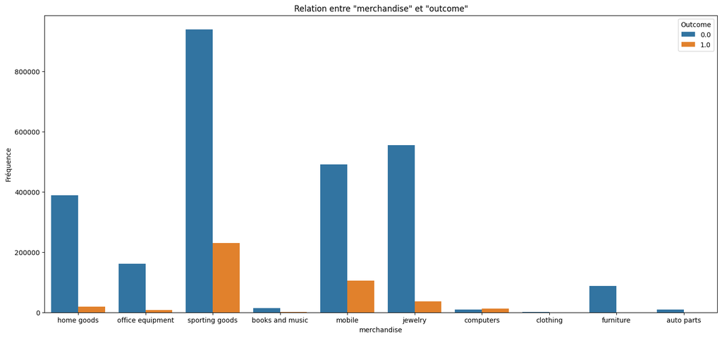

```python
# Définir la taille de la figure avec seaborn
plt.figure(figsize=(18, 8))

# Afficher le diagramme en barres empilées pour 'device' par rapport à 'outcome'
sns.countplot(x='merchandise', hue='outcome', data=Clean_data)

# Ajouter des étiquettes et un titre
plt.xlabel('merchandise')
plt.ylabel('Fréquence')
plt.title('Relation entre "merchandise" et "outcome"')

# Afficher la légende
plt.legend(title='Outcome', loc='upper right')

# Afficher le diagramme
plt.show()
```

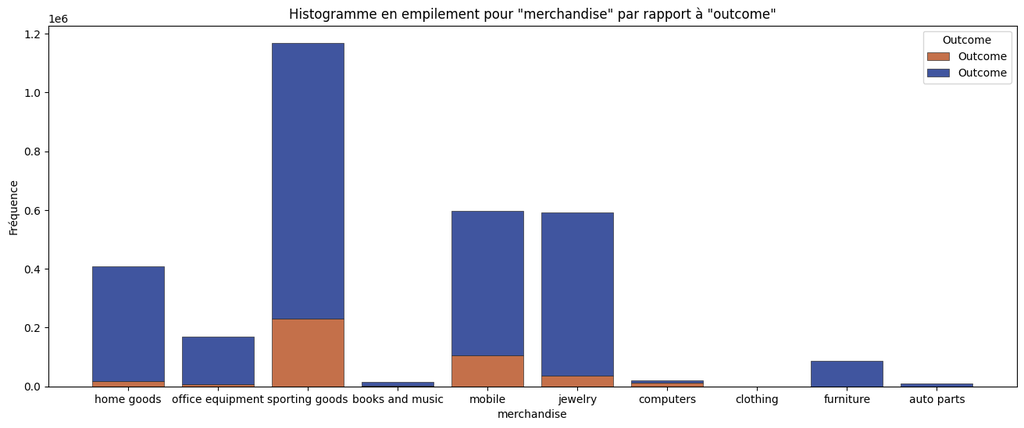

```python
plt.figure(figsize=(16, 6))

# Afficher l'histogramme en empilement pour 'device' par rapport à 'outcome'
sns.histplot(x='merchandise', hue='outcome', data=Clean_data, multiple='stack', shrink=0.8,
             element='bars', stat='count', common_norm=False,
             palette='dark', edgecolor='.2', lw=.5, label='Outcome')

# Ajouter des étiquettes et un titre
plt.xlabel('merchandise')
plt.ylabel('Fréquence')
plt.title('Histogramme en empilement pour "merchandise" par rapport à "outcome"')

# Afficher la légende
plt.legend(title='Outcome', loc='upper right')

# Afficher l'histogramme
plt.show()
```

```python
table = pd.crosstab(index=Clean_data['merchandise'], columns=Clean_data['outcome'])
```

```python
table
```

| outcome merchandise | 0.0 | 1.0 |
| --- | --- | --- |
| auto parts | 9757 | 0 |
| books and music | 13667 | 1507 |
| clothing | 476 | 0 |
| computers | 9730 | 11667 |
| furniture | 87306 | 0 |
| home goods | 389209 | 18679 |
| jewelry | 555111 | 37008 |
| mobile | 491593 | 105111 |
| office equipment | 160429 | 7945 |
| sporting goods | 939092 | 230236 |

**Passons à la variable `country`**

### Country

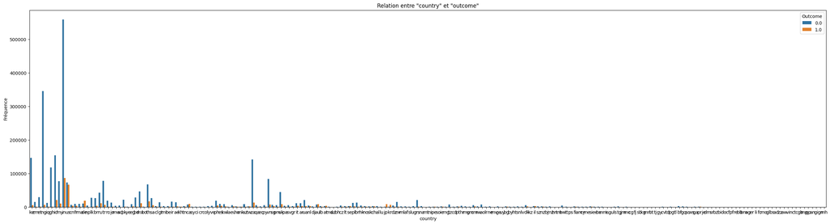

```python
# Définir la taille de la figure avec seaborn 3068523
plt.figure(figsize=(32, 8))

# Afficher le diagramme en barres empilées pour 'device' par rapport à 'outcome'
sns.countplot(x='country', hue='outcome', data=Clean_data)

# Ajouter des étiquettes et un titre
plt.xlabel('country')
plt.ylabel('Fréquence')
plt.title('Relation entre "country" et "outcome"')

# Afficher la légende
plt.legend(title='Outcome', loc='upper right')

# Afficher le diagramme
plt.show()
```

Le schéma ci-dessus montre la distribution de la variable `country` par rapport à la variable cible. On peut déjà y observer une distribution très inégale des pays (des barres plus longues que d'autres; certaines quasiment inexistantes). Nous utiliserons d'autres formats afin de mieux comprendre la variable `country`

```python
# Create a cross-tabulation of 'country' and 'outcome'
table = pd.crosstab(index=Clean_data['country'], columns=Clean_data['outcome'])

# Add a column for the total count of each 'country'
table['Total'] = table.sum(axis=1)

# Sort the table by the total count of each 'country' in ascending order
table_sorted = table.sort_values(by='Total', ascending=False)
```

Le tableau ci-dessous nous montre le nombre total d'occurence de chaque pays dans notre base de données. Il précise par ailleurs pour chaque pays, la part de chaque `outcome` dans ce nombre total. A titre d'exemple pour l'Inde (`in`) nous avons `645631` enchères placées dont `86386` placées par les robots et `559245` enchères qui ne sont pas placées des robots.

```python
table_sorted
```

| outcome country | 0.0 | 1.0 | Total |
| --- | --- | --- | --- |
| in | 559245 | 86386 | 645631 |
| ng | 345411 | 6852 | 352263 |
| id | 153733 | 20495 | 174228 |
| za | 141974 | 13364 | 155338 |
| ke | 146322 | 5385 | 151707 |
| ... | ... | ... | ... |
| gi | 0 | 1 | 1 |
| gn | 1 | 0 | 1 |
| an | 0 | 1 | 1 |
| mh | 1 | 0 | 1 |
| tc | 0 | 1 | 1 |

198 rows × 3 columns

```python
table_sorted.describe()
```

| outcome | 0.0 | 1.0 | Total |
| --- | --- | --- | --- |
| count | 198.000000 | 198.000000 | 198.000000 |
| mean | 13416.010101 | 2081.580808 | 15497.590909 |
| std | 51366.426360 | 8238.020367 | 57728.973734 |
| min | 0.000000 | 0.000000 | 1.000000 |
| 25% | 137.250000 | 13.000000 | 167.250000 |
| 50% | 1433.500000 | 131.000000 | 1717.500000 |
| 75% | 5598.750000 | 728.750000 | 7125.500000 |
| max | 559245.000000 | 86386.000000 | 645631.000000 |

- L'observation du tableau précédent et des statistiques ci-dessus confirme le fait que la répartition des pays soit très inégale. En effet, chaque pays apparaît en moyenne environ `15497` fois avec écart type très grand par rapport à cette moyenne qui est de `57728.973734`.
- La médiane `1717.500000` est très basse par rapport à la moyenne. Ce qui indique une certaine asymétrie avec l'existance de certains pays avec un d'occurence très grand nombre faisant augmenter la moyenne.
- Par ailleurs, `75%` des pays apparaissent moins `7125` fois. Donc les 25% des pays restants apparaissent trop souvent.

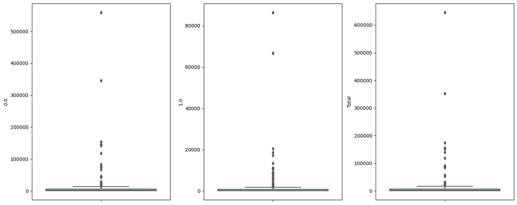

```python
variable_names = [0.0, 1.0, 'Total']

# Créer des sous-graphiques pour chaque variable
fig, axes = plt.subplots(nrows=1, ncols=len(variable_names), figsize=(15, 6))

# Tracer les boxplots sur les sous-graphiques
for i, variable in enumerate(variable_names):
    sns.boxplot(y=variable, data=table_sorted, ax=axes[i], palette='Set2')

# Ajuster l'espacement entre les sous-graphiques
plt.tight_layout()

# Afficher le graphique
plt.show()
```

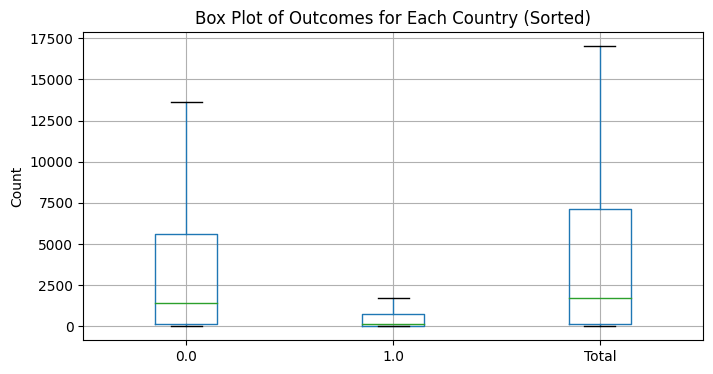

```python
columns_for_boxplot = table_sorted.columns[0:]  # Exclude the 'Total' column

# Create a box plot
plt.figure(figsize=(8, 4))
table_sorted[columns_for_boxplot].boxplot(sym='k+', showfliers=False)
#plt.xlabel('Outcome')
plt.ylabel('Count')
plt.title('Box Plot of Outcomes for Each Country (Sorted)')
plt.show()
```

```python
# Filter the table based on the condition
filtered_table = table[table[1.0] > table[0.0]]
filtered_table_sorted = filtered_table.sort_values(by='Total', ascending=False)
print(filtered_table_sorted.shape)
```

```
(26, 3)
```

Nous avons au total 26 pays dans lesquels les enchères sont le plus souvent emises par des robots. Dans la suite, ceci pemermttra probablement d'expliquer les résultats de la prédiction.

```python
filtered_table_sorted
```

| outcome country | 0.0 | 1.0 | Total |
| --- | --- | --- | --- |
| de | 10436 | 18530 | 28966 |
| ca | 7804 | 9205 | 17009 |
| au | 7756 | 8634 | 16390 |
| jp | 498 | 7921 | 8419 |
| kr | 634 | 6340 | 6974 |
| at | 2445 | 3407 | 5852 |
| mn | 33 | 134 | 167 |
| mo | 3 | 140 | 143 |
| do | 22 | 63 | 85 |
| tm | 10 | 43 | 53 |
| ps | 19 | 29 | 48 |
| sr | 17 | 22 | 39 |
| dm | 4 | 13 | 17 |
| pf | 5 | 9 | 14 |
| nc | 0 | 11 | 11 |
| fo | 1 | 8 | 9 |
| bs | 2 | 7 | 9 |
| ag | 3 | 6 | 9 |
| je | 1 | 7 | 8 |
| vi | 0 | 8 | 8 |
| aw | 0 | 7 | 7 |
| mp | 1 | 5 | 6 |
| gp | 0 | 2 | 2 |
| an | 0 | 1 | 1 |
| gi | 0 | 1 | 1 |
| tc | 0 | 1 | 1 |

```python
filtered_table_sorted.describe()
```

| outcome | 0.0 | 1.0 | Total |
| --- | --- | --- | --- |
| count | 26.000000 | 26.000000 | 26.000000 |
| mean | 1142.076923 | 2098.230769 | 3240.307692 |
| std | 2847.353788 | 4484.475009 | 7149.274933 |
| min | 0.000000 | 1.000000 | 1.000000 |
| 25% | 0.250000 | 7.000000 | 8.000000 |
| 50% | 3.500000 | 12.000000 | 15.500000 |
| 75% | 30.250000 | 138.500000 | 161.000000 |
| max | 10436.000000 | 18530.000000 | 28966.000000 |

### Adresse ip

```python
# Créer un tableau de contingence
contingency_table = pd.crosstab(Clean_data['ip'], [Clean_data['country']])

# Appliquer le test du Chi2
chi2_stat, p_value, dof, expected = chi2_contingency(contingency_table)

# Afficher les résultats
print("Statistique du Chi2 :", chi2_stat)
print("P-value :", p_value)
print("Degrés de liberté :", dof)
#print("Tableau Attendu :", expected)
```

```
Statistique du Chi2 : 597430221.7141631
P-value : 0.0
Degrés de liberté : 202675373
```

Ces résultats indiquent qu'il existe une association significative entre les adresses IP (ip) et les pays (country). En effet, la `p_value` vaut zéro (0.0), ce qui signifie que la probabilité d'obtenir une statistique de test Chi2 aussi extrême (ou plus extrême) sous l'hypothèse nulle d'indépendance est très faible. Cela pourrait signifier que certaines adresses IP sont associées de manière non aléatoire à des pays spécifiques, et vice versa. Cela confirme d'ailleurs les soupçons qui nous ont amené à faire ce test. En effet, une adresse `ip` est associée à un unique pays. Au quel cas, l'information portée par les deux variables pourrait être entièrement contenue dans la variables `pays`. Cependant, nous allons retenir les deux varibles pour observer l'impact sur nos modèles.

```python
# Créer un tableau de contingence
contingency_table2 = pd.crosstab(Clean_data['ip'], [Clean_data['url']])
contingency_table2
```

```python
# Appliquer le test du Chi2
chi2_stat, p_value, dof, expected = chi2_contingency(contingency_table)

# Afficher les résultats
print("Statistique du Chi2 :", chi2_stat)
print("P-value :", p_value)
print("Degrés de liberté :", dof)
```

[output not shown]

### Device

```python
Clean_data['device'].describe()
```

```
count     3068523
unique       5726
top        phone4
freq       306994
Name: device, dtype: object
```

```python
Clean_data['device'].value_counts()
```

```
phone4       306994
phone35       75535
phone101      69737
phone2        67181
phone45       64156
              ...
phone6569         1
phone6628         1
phone3761         1
phone6450         1
phone3688         1
Name: device, Length: 5726, dtype: int64
```

La variable `device` contient `5726` valeurs uniques. Cette variable semble désigner l'appareil à sur lequel l'enchère a été reçu. Entre autres le `device` "`phone4`" est l'appareil le plus utilisé avec `306994` occurences et les appareils les moins utilisés ne l'ont été qu'une seule fois.

```python
table_cross_device = pd.crosstab(index=Clean_data['device'], columns=Clean_data['outcome'])
```

```python
table_cross_device['Total'] = table_cross_device.sum(axis=1)

# Sort the table by the total count of each 'country' in ascending order
table_sorted = table_cross_device.sort_values(by='Total', ascending=False)
table_sorted
```

| outcome device | 0.0 | 1.0 | Total |
| --- | --- | --- | --- |
| phone4 | 292892 | 14102 | 306994 |
| phone35 | 72861 | 2674 | 75535 |
| phone101 | 67189 | 2548 | 69737 |
| phone2 | 62787 | 4394 | 67181 |
| phone45 | 61565 | 2591 | 64156 |
| ... | ... | ... | ... |
| phone6096 | 0 | 1 | 1 |
| phone6095 | 1 | 0 | 1 |
| phone4924 | 0 | 1 | 1 |
| phone3013 | 1 | 0 | 1 |
| phone6083 | 1 | 0 | 1 |

5726 rows × 3 columns

```python
# Filtrer les lignes où la valeur associée à la classe "1.0" est supérieure ou égale à la valeur associée à la classe "0.0"
filtered_rows = table_sorted[table_sorted[1.0] >= table_sorted[0.0]]

# Ordonner ces valeurs par ordre décroissant
sorted_rows = filtered_rows.sort_values(by=[1.0], ascending=False)

# Afficher le DataFrame résultant
sorted_rows
```

| outcome device | 0.0 | 1.0 | Total |
| --- | --- | --- | --- |
| phone119 | 2982 | 14825 | 17807 |
| phone62 | 6911 | 9404 | 16315 |
| phone115 | 1369 | 4773 | 6142 |
| phone122 | 1244 | 4751 | 5995 |
| phone237 | 2603 | 4187 | 6790 |
| ... | ... | ... | ... |
| phone7444 | 0 | 1 | 1 |
| phone7434 | 0 | 1 | 1 |
| phone7428 | 0 | 1 | 1 |
| phone7421 | 0 | 1 | 1 |
| phone4924 | 0 | 1 | 1 |

1375 rows × 3 columns

Vue le déséquilibre observé dans la base de donnée comme on s'y attendait, pour la plupart des `device` l'`outcome` `0.0` domine l'`outcome` `1.0`. Néanmoins, pour `1375` `device`, l'`outcome` `1.0` domine l'`outcome` `0.0`.

### Time

Une autre variable qui nous apparait important de comprendre est la variable `time`. Notre première appréhension est qu'elle représente l'instant où la transaction a eu lieu. La grandeur des chiffres semble représenté le nombre de milisecondes écoulées depuis environ 1997 jusqu'à la date d'émission des enchères. Cette colonne semble porteuse d'information et nous la normaliserons afin de l'utiliser pour la prédiction.

```python
import pandas as pd
from sklearn.preprocessing import StandardScaler
import matplotlib.pyplot as plt
import seaborn as sns

import pandas as pd
from sklearn.preprocessing import StandardScaler


# Créer une copie du DataFrame d'origine
df_copy = Clean_data.copy()

# Sélectionner les colonnes à normaliser
columns_to_normalize = ["time"]

# Créer un objet StandardScaler
scaler = StandardScaler()

# Normaliser les données
df_copy[["time"]] = scaler.fit_transform(df_copy[["time"]])

# Créer un nouveau DataFrame avec les colonnes normalisées et "outcome"
new_df = df_copy[["time", "outcome"]]
```

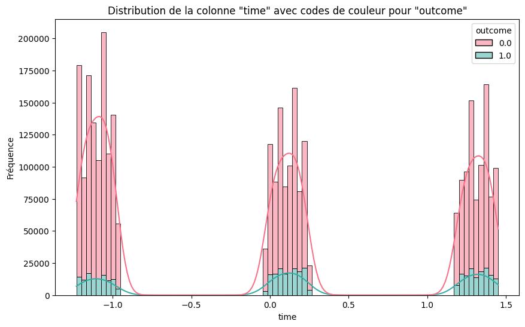

```python
# Afficher la distribution de la colonne normalisée avec codes de couleur pour "outcome"
plt.figure(figsize=(10, 6))
sns.histplot(data=df_copy, x="time", hue="outcome", kde=True, multiple="stack", palette="husl")
plt.title('Distribution de la colonne "time" avec codes de couleur pour "outcome"')
plt.xlabel('time')
plt.ylabel('Fréquence')
# plt.legend(title="Outcome", labels=["1", "0"])
plt.show()
```

Le regroupement par lot du graph précédent montre que les enchères sont emises à des moments spécifiques. Sans suprise, les `outcome` "0.0" domine les `outcome` "1.0".

# Modélisation Prédictive

```python
from sklearn.pipeline import Pipeline
from sklearn.compose import ColumnTransformer

from imblearn.under_sampling import RandomUnderSampler
from sklearn.model_selection import train_test_split
#from sklearn.impute import SimpleImputer
from sklearn.preprocessing import OneHotEncoder, StandardScaler
from sklearn.model_selection import train_test_split
from sklearn.metrics import accuracy_score
from sklearn.metrics import confusion_matrix
from sklearn.preprocessing import LabelEncoder
from sklearn.metrics import classification_report
from sklearn.preprocessing import StandardScaler, LabelEncoder
from sklearn.neighbors import KNeighborsClassifier
```

```python
from sklearn.linear_model import LogisticRegression
from sklearn.ensemble import RandomForestClassifier
from sklearn.svm import SVC
```

```python
from sklearn.model_selection import cross_val_score
from sklearn.metrics import make_scorer, recall_score
from sklearn.model_selection import GridSearchCV
```

Dans la section suivante nous allons définir les dataset que nous utiliserons pour la prédiction.

- Premièrement, nous allons définir une base de données contenant toutes les lignes ainsi que les colonnes à l'exception des varaibles `'payment_account','address'`.Ensuite, nous supprimerons également la colonne `bidder_id` afin de constituer la deuxième dataset. L'objectif est d'analyse l'impact de la colonne `bidder_id` sur les prédiction. Cette initiative vient de la remarque selon laquelle toutes les occurences d'un même `bidder_id` possèdent la même sortie (`outcome`). Cela amène à penser que la seule connaissance de la colonne `bidder_id` permet de déterminer la prédiction.
- Dans un second temps, pour contrebalancer le déséquilibre de la base données, nous utiliserons les techniques d'échantillons et cette fois ci encore nous essayerons la prédiction avec et sans `bidder_id`

```python
# @title Création du dataset avec bidder_id
data_bidder_id = Clean_data.drop(['bid_id', 'payment_account','address'], axis = 1)
X_train_bidder, X_test_bidder, y_train_bidder, y_test_bidder = train_test_split(data_bidder_id.drop('outcome', axis=1), data_bidder_id['outcome'], test_size=0.2, random_state=42)
```

```python
# @title Création du dataset sans bidder_id
data= Clean_data.drop(['bidder_id','bid_id', 'payment_account','address'], axis = 1)

X_train, X_test, y_train, y_test = train_test_split(data.drop('outcome', axis=1), data['outcome'], test_size=0.2, random_state=42)
```

```python
# @title Sous-échantillonage du dataset avec bidder_id
rus = RandomUnderSampler(random_state=42)
X_resampled_bidder, y_resampled_bidder = rus.fit_resample(X_train_bidder, y_train_bidder)
```

```python
# @title Sous-échantillonage de la base de données sans bidder_id
rus = RandomUnderSampler(random_state=42)
X_resampled, y_resampled = rus.fit_resample(X_train, y_train)
```

Après cette première phase de split et d'échantillonnage de la base de données, nous possédons à l'implémetation des algorithmes. Le premier que nous essaierons est la regression logistique.

## Regression logistique

### Utilisation de toute la donnée avec la colonne bidder_id

Nous implémentons une première version sur l'ensemble de la base de donnée en gardant la colonne `bidder_id`. L'idée est de constater l'influence de la dite colonne et de l'usage des données entières sur les performances de l'algorithme. Sur les données catégorielles nous appliquons le `OneHotEncoder` pour les transformer en colonnes binaires, créant ainsi de nouveaux features. Pour la donnée numérique, la normalisation `StandardScaler` est appliquée.

```python
# Définir les étapes de prétraitement pour les variables catégorielles
categorical_transformer = Pipeline(steps=[
    ('onehot', OneHotEncoder(handle_unknown='ignore'))  # Encodage one-hot
])

# Définir les étapes de prétraitement pour les variables numériques
numeric_transformer = Pipeline(steps=[
    ('scaler', StandardScaler())  # Standardisation
])

categorical_features = ['bidder_id', 'auction', 'merchandise', 'device', 'country', 'ip', 'url']
numeric_features = ['time']

# Créer la colonne transformer
preprocessor = ColumnTransformer(
    transformers=[
        ('num', numeric_transformer, numeric_features),
        ('cat', categorical_transformer, categorical_features)
    ])
preprocessor
```

```
ColumnTransformer(transformers=[('num',
                                 Pipeline(steps=[('scaler', StandardScaler())]),
                                 ['time']),
                                ('cat',
                                 Pipeline(steps=[('onehot',
                                                  OneHotEncoder(handle_unknown='ignore'))]),
                                 ['bidder_id', 'auction', 'merchandise',
                                  'device', 'country', 'ip', 'url'])])
```

```python
LR_model = Pipeline(steps=[('preprocessor', preprocessor),
                             ('classifier', LogisticRegression(C = 1))])

# Entraîner le modèle en utilisant la pipeline
LR_model.fit(X_train_bidder, y_train_bidder)
```

```
Pipeline(steps=[('preprocessor',
                 ColumnTransformer(transformers=[('num',
                                                  Pipeline(steps=[('scaler',
                                                                   StandardScaler())]),
                                                  ['time']),
                                                 ('cat',
                                                  Pipeline(steps=[('onehot',
                                                                   OneHotEncoder(handle_unknown='ignore'))]),
                                                  ['bidder_id', 'auction',
                                                   'merchandise', 'device',
                                                   'country', 'ip', 'url'])])),
                ('classifier', LogisticRegression(C=1))])
```

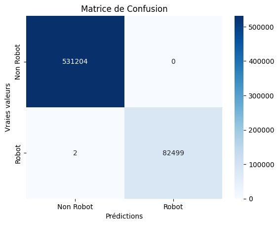

```
Rapport de Classification :
              precision    recall  f1-score   support

         0.0       1.00      1.00      1.00    531204
         1.0       1.00      1.00      1.00     82501

    accuracy                           1.00    613705
   macro avg       1.00      1.00      1.00    613705
weighted avg       1.00      1.00      1.00    613705
```

```python
# Prédire sur l'ensemble de test
y_pred_bidder = LR_model.predict(X_test_bidder)

# Calculez la matrice de confusion
conf_matrix = confusion_matrix(y_test_bidder, y_pred_bidder)
# Affichez la matrice de confusion sous forme de heatmap
sns.heatmap(conf_matrix, annot=True, fmt='d', cmap='Blues', xticklabels=['Non Robot', 'Robot'], yticklabels=['Non Robot', 'Robot'])
plt.xlabel('Prédictions')
plt.ylabel('Vraies valeurs')
plt.title('Matrice de Confusion')
plt.show()

# Afficher le rapport de classification
class_report_bidder = classification_report(y_test_bidder, y_pred_bidder)
print("Rapport de Classification :")
print(class_report_bidder)
```

On remarque que l'algorithme performe très bien, détectant aussi bien les enchères placées par les robots que celles non placées par les robots. Il prédit d'ailleurs avec une précison de 1, les enchères non placées par les robots. Et ne rate que 2 prédictions dans l'autre cas. Ceci pourrait avoir 2 explications. Dans un premier temps, on pourrait attribuer cela au nombre important de données qui lui permet une bonne analyse. Mais cette performance semble plus liée à la présence de la colonne `bidder_id`. En effet, même sans l'implémentation d'un algorithme, une façon de prédire est la suivante: pour chaque donnée à prédire, on s'interesse à la colonne `bidder_id` de la donnée. Il suffit de choisir donc dans les données d'entrainement le groupe de données qui a le même `bidder_id` que ce dernier et de lui attribuer le valeur de `outcome` de ce groupe (qui remarquons, est le même). Pour toute donnée dont le `bidder_id` n'est pas dans les données d'entrainement, il suffit par exemple d'attribuer la classe majoritaire.

Afin de mieux constater les performances de l'algorithme et pour confirmer nos hypothèses, nous supprimons la colonne `bidder_id` pouis nous reprenons les tests. Les mêmes encoding sont conservées.

### Utilisation de toute la donnée sans la colonne bidder_id

```python
# Définir les étapes de prétraitement pour les variables catégorielles

categorical_transformer = Pipeline(steps=[
    ('onehot', OneHotEncoder(handle_unknown='ignore'))  # Encodage one-hot
])

# Définir les étapes de prétraitement pour les variables numériques
numeric_transformer = Pipeline(steps=[
    ('scaler', StandardScaler())  # Standardisation
])

categorical_features = ['auction', 'merchandise', 'device', 'country', 'ip', 'url']
numeric_features = ['time']

# Créer la colonne transformer
preprocessor = ColumnTransformer(
    transformers=[
        ('num', numeric_transformer, numeric_features),
        ('cat', categorical_transformer, categorical_features)
    ])
preprocessor
```

```
ColumnTransformer(transformers=[('num',
                                 Pipeline(steps=[('scaler', StandardScaler())]),
                                 ['time']),
                                ('cat',
                                 Pipeline(steps=[('onehot',
                                                  OneHotEncoder(handle_unknown='ignore'))]),
                                 ['auction', 'merchandise', 'device', 'country',
                                  'ip', 'url'])])
```

```python
LR_model = Pipeline(steps=[('preprocessor', preprocessor),
                             ('classifier', LogisticRegression(C = 1))])

# Entraîner le modèle en utilisant la pipeline
LR_model.fit(X_train, y_train)
```

```
Pipeline(steps=[('preprocessor',
                 ColumnTransformer(transformers=[('num',
                                                  Pipeline(steps=[('scaler',
                                                                   StandardScaler())]),
                                                  ['time']),
                                                 ('cat',
                                                  Pipeline(steps=[('onehot',
                                                                   OneHotEncoder(handle_unknown='ignore'))]),
                                                  ['auction', 'merchandise',
                                                   'device', 'country', 'ip',
                                                   'url'])])),
                ('classifier', LogisticRegression(C=1))])
```

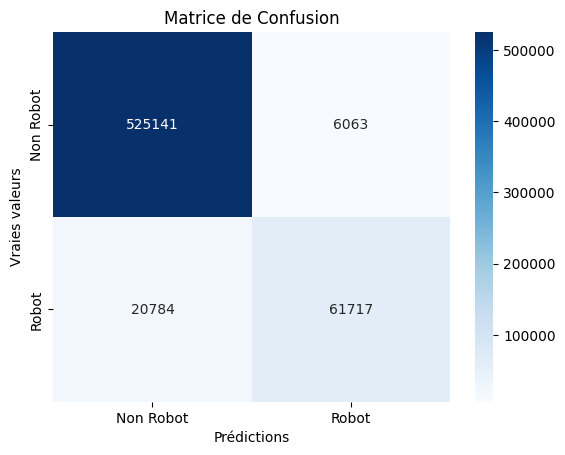

```
Rapport de Classification :
              precision    recall  f1-score   support

         0.0       0.96      0.99      0.98    531204
         1.0       0.91      0.75      0.82     82501

    accuracy                           0.96    613705
   macro avg       0.94      0.87      0.90    613705
weighted avg       0.96      0.96      0.95    613705
```

```python
# Prédire sur l'ensemble de test
y_pred = LR_model.predict(X_test)

# Calculez la matrice de confusion
conf_matrix = confusion_matrix(y_test, y_pred)
# Affichez la matrice de confusion sous forme de heatmap
sns.heatmap(conf_matrix, annot=True, fmt='d', cmap='Blues', xticklabels=['Non Robot', 'Robot'], yticklabels=['Non Robot', 'Robot'])
plt.xlabel('Prédictions')
plt.ylabel('Vraies valeurs')
plt.title('Matrice de Confusion')
plt.show()

# Afficher le rapport de classification
class_report = classification_report(y_test, y_pred)
print("Rapport de Classification :")
print(class_report)
```

La différence dans les résultats de prédiction est flagrante. L'accuracy de 96% pourrait indiquer une très bonne performance. Mais en s'interessant de près aux résultats de la prédiction et typiquement au `recall` on constate que l'algorithme ne performe pas tant bien. En effet, étant biaisé par le déséquilibre des `outcome`, il se contente de classer la plupart des données dans la classe majoritaire. `20784` enchères sont des classés comme des enchères émises par des non robots pendant qu'elles sont belle et bien émises par des robots. Pourtant on peut bien facilement imaginer que pour une entreprise les enchères émises par les robots sont celles qui sont les plus pertinentes à prédire. C'est donc sur l'optimisation du recall que nous nous attarderons. Pour contrecarrer le déséquilibre priorisant la classe `0`, nous faisons un sous-échantillonnage sur les données d'entrainement. Les résultats sont comparées par contre sur les mêmes ensembles de données de test afin de faire des comparaisons dans les mêmes conditions. Dans un premier temps, nous remettons la colonne `bidder_id` dans le jeu de données.

### Utilisation du sous-échantillon avec la colonne bidder_id

```python
# Définir les étapes de prétraitement pour les variables catégorielles
categorical_transformer = Pipeline(steps=[
    ('onehot', OneHotEncoder(handle_unknown='ignore'))  # Encodage one-hot
])

# Définir les étapes de prétraitement pour les variables numériques
numeric_transformer = Pipeline(steps=[
    ('scaler', StandardScaler())  # Standardisation
])

categorical_features = ['bidder_id', 'auction', 'merchandise', 'device', 'country', 'ip', 'url']
numeric_features = ['time']

# Créer la colonne transformer
preprocessor = ColumnTransformer(
    transformers=[
        ('num', numeric_transformer, numeric_features),
        ('cat', categorical_transformer, categorical_features)
    ])
preprocessor
```

```
ColumnTransformer(transformers=[('num',
                                 Pipeline(steps=[('scaler', StandardScaler())]),
                                 ['time']),
                                ('cat',
                                 Pipeline(steps=[('onehot',
                                                  OneHotEncoder(handle_unknown='ignore'))]),
                                 ['bidder_id', 'auction', 'merchandise',
                                  'device', 'country', 'ip', 'url'])])
```

```python
LR_model = Pipeline(steps=[('preprocessor', preprocessor),
                             ('classifier', LogisticRegression(C = 1))])

# Entraîner le modèle en utilisant la pipeline
LR_model.fit(X_resampled_bidder, y_resampled_bidder)
```

```
Pipeline(steps=[('preprocessor',
                 ColumnTransformer(transformers=[('num',
                                                  Pipeline(steps=[('scaler',
                                                                   StandardScaler())]),
                                                  ['time']),
                                                 ('cat',
                                                  Pipeline(steps=[('onehot',
                                                                   OneHotEncoder(handle_unknown='ignore'))]),
                                                  ['bidder_id', 'auction',
                                                   'merchandise', 'device',
                                                   'country', 'ip', 'url'])])),
                ('classifier', LogisticRegression(C=1))])
```

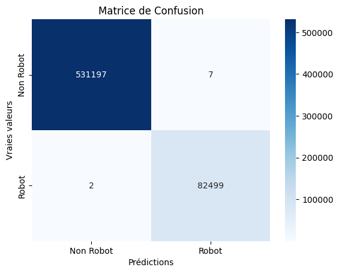

```
Rapport de Classification :
              precision    recall  f1-score   support

         0.0       1.00      1.00      1.00    531204
         1.0       1.00      1.00      1.00     82501

    accuracy                           1.00    613705
   macro avg       1.00      1.00      1.00    613705
weighted avg       1.00      1.00      1.00    613705
```

```python
# Prédire sur l'ensemble de test
y_pred_bidder = LR_model.predict(X_test_bidder)

# Calculez la matrice de confusion
conf_matrix = confusion_matrix(y_test_bidder, y_pred_bidder)
# Affichez la matrice de confusion sous forme de heatmap
sns.heatmap(conf_matrix, annot=True, fmt='d', cmap='Blues', xticklabels=['Non Robot', 'Robot'], yticklabels=['Non Robot', 'Robot'])
plt.xlabel('Prédictions')
plt.ylabel('Vraies valeurs')
plt.title('Matrice de Confusion')
plt.show()

# Afficher le rapport de classification
class_report_bidder = classification_report(y_test_bidder, y_pred_bidder)
print("Rapport de Classification :")
print(class_report_bidder)
```

Le résultats obtenu est très bon. Les deux classes sont prédites de façon remarquable. Cela cependant est encore une fois dû à la présence de la colonne `bidder_id`. Mais en comparaison par rapport au premier(utilisation de toute la donnée avec la colonne `bidder_id`, on peut dire que le fait d'avoir moins de données entraine une performance légèrement moins bonne quand on s'interesse à la matrice de confusion. Enfin nous supprimons encore cette colonne pour éprouver le modèle sur les échantillons.

### Utilisation du sous-échantillon sans la colonne bidder_id

```python
# Définir les étapes de prétraitement pour les variables catégorielles
categorical_transformer = Pipeline(steps=[
    ('onehot', OneHotEncoder(handle_unknown='ignore'))  # Encodage one-hot
])

# Définir les étapes de prétraitement pour les variables numériques
numeric_transformer = Pipeline(steps=[
    ('scaler', StandardScaler())  # Standardisation
])

categorical_features = [ 'auction', 'merchandise', 'device', 'country', 'ip', 'url']
numeric_features = ['time']

# Créer la colonne transformer
preprocessor = ColumnTransformer(
    transformers=[
        ('num', numeric_transformer, numeric_features),
        ('cat', categorical_transformer, categorical_features)
    ])
preprocessor
```

```
ColumnTransformer(transformers=[('num',
                                 Pipeline(steps=[('scaler', StandardScaler())]),
                                 ['time']),
                                ('cat',
                                 Pipeline(steps=[('onehot',
                                                  OneHotEncoder(handle_unknown='ignore'))]),
                                 ['auction', 'merchandise', 'device', 'country',
                                  'ip', 'url'])])
```

```python
LR_model = Pipeline(steps=[('preprocessor', preprocessor),
                             ('classifier', LogisticRegression(C = 1))])

# Entraîner le modèle en utilisant la pipeline
LR_model.fit(X_resampled, y_resampled)
```

```
Pipeline(steps=[('preprocessor',
                 ColumnTransformer(transformers=[('num',
                                                  Pipeline(steps=[('scaler',
                                                                   StandardScaler())]),
                                                  ['time']),
                                                 ('cat',
                                                  Pipeline(steps=[('onehot',
                                                                   OneHotEncoder(handle_unknown='ignore'))]),
                                                  ['auction', 'merchandise',
                                                   'device', 'country', 'ip',
                                                   'url'])])),
                ('classifier', LogisticRegression(C=1))])
```

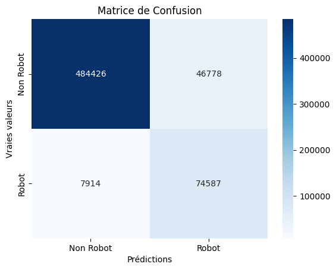

```
Rapport de Classification :
              precision    recall  f1-score   support

         0.0       0.98      0.91      0.95    531204
         1.0       0.61      0.90      0.73     82501

    accuracy                           0.91    613705
   macro avg       0.80      0.91      0.84    613705
weighted avg       0.93      0.91      0.92    613705
```

```python
# Prédire sur l'ensemble de test
y_pred = LR_model.predict(X_test)

# Calculez la matrice de confusion
conf_matrix = confusion_matrix(y_test, y_pred)
# Affichez la matrice de confusion sous forme de heatmap
sns.heatmap(conf_matrix, annot=True, fmt='d', cmap='Blues', xticklabels=['Non Robot', 'Robot'], yticklabels=['Non Robot', 'Robot'])
plt.xlabel('Prédictions')
plt.ylabel('Vraies valeurs')
plt.title('Matrice de Confusion')
plt.show()

# Afficher le rapport de classification
class_report = classification_report(y_test, y_pred)
print("Rapport de Classification :")
print(class_report)
```

- Dans ce cas, le modèle a une bonne perfomance sur la prédiction des enchères placées par les robots. Cela s'observe par le `recall` du modèle qui est de 90% comparé à celui observé premièrement sur toute la donnée d'entrainement sans faire du rééquilibrage (75%).
- Pour une conclusion partielle, la comparaison des quatres tests précédents nous permet de dire que la meilleure méthode pour prédire les enchères placées par des robots est celle qui consiste à utiliser toute la base de données ainsi que la colonne `bidder_id`. Cependant, le grand défaut de cette méthode est sa trop grande dépendance de la colonne `bidder_id`. Pour de nouveaux arrivants, l'algorithme aurait du mal à s'adapter. Au vue de cela, il est préférable d'adopter le dernier algorithme implémenté (sans `bidder_id` + sous-échantillonnage de la donnée d'entrainement).
- Dans une dernière tentative d'améloration du modèle retenu, nous implémenterons une cross-validation avec pour objectif, l'optimisation du `recall`.

### Cross validation du sous-échantillon sans la colonne bidder_id

[output not shown]

[output cut: 225 more lines]

[output not shown]

```
Meilleurs paramètres : {'classifier__C': 100}
Rapport de Classification :
              precision    recall  f1-score   support

         0.0       0.98      0.91      0.95    531204
         1.0       0.62      0.90      0.73     82501

    accuracy                           0.91    613705
   macro avg       0.80      0.91      0.84    613705
weighted avg       0.93      0.91      0.92    613705
```

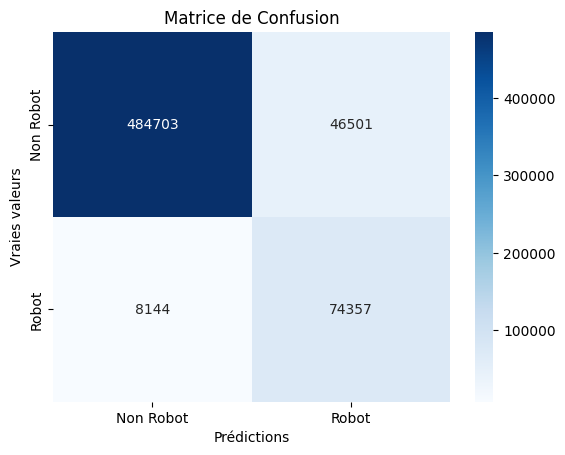

```python
# Logistic Regression Model
LR_model = Pipeline(steps=[
    ('preprocessor', preprocessor),
    ('classifier', LogisticRegression())
])

# Définir la plage de valeurs pour les paramètres à rechercher
param_grid = {'classifier__C': [ 0.01, 0.1, 0.2, 0.5, 1, 10, 100]}

# Recherche de grille avec validation croisée
grid_search = GridSearchCV(LR_model, param_grid, cv=5, scoring='recall')
grid_search.fit(X_resampled, y_resampled)

# Afficher les meilleurs paramètres
print("Meilleurs paramètres :", grid_search.best_params_)

# Utiliser le meilleur modèle trouvé
best_LR_model = grid_search.best_estimator_

# Prédire sur l'ensemble de test
y_lr = best_LR_model.predict(X_test)

# Afficher le rapport de classification
class_report = classification_report(y_test, y_lr)
print("Rapport de Classification :")
print(class_report)

# Calculez la matrice de confusion
conf_matrix = confusion_matrix(y_test, y_lr)

# Affichez la matrice de confusion sous forme de heatmap
sns.heatmap(conf_matrix, annot=True, fmt='d', cmap='Blues', xticklabels=['Non Robot', 'Robot'], yticklabels=['Non Robot', 'Robot'])
plt.xlabel('Prédictions')
plt.ylabel('Vraies valeurs')
plt.title('Matrice de Confusion')
plt.show()
```

## Randomforest

### RandomForest avec bidder_id sur toute les données

```python
# Créer un objet LabelEncoder
label_encoder = LabelEncoder()

categorical_features = ['bidder_id', 'auction', 'merchandise', 'device', 'country', 'ip', 'url']
numeric_features = ['time']


# Normaliser les time
scaler = StandardScaler()
data_bidder_id[numeric_features] = scaler.fit_transform(data_bidder_id[numeric_features])

# Appliquer Label Encoding aux variables catégorielles
for feature in categorical_features:
    data_bidder_id[feature] = label_encoder.fit_transform(data_bidder_id[feature])


X_train, X_test, y_train, y_test = train_test_split(data_bidder_id.drop('outcome', axis=1), data_bidder_id['outcome'], test_size=0.2, random_state=42)
```

```
Rapport de Classification :
              precision    recall  f1-score   support

         0.0       1.00      1.00      1.00    531204
         1.0       1.00      0.99      1.00     82501

    accuracy                           1.00    613705
   macro avg       1.00      1.00      1.00    613705
weighted avg       1.00      1.00      1.00    613705
```

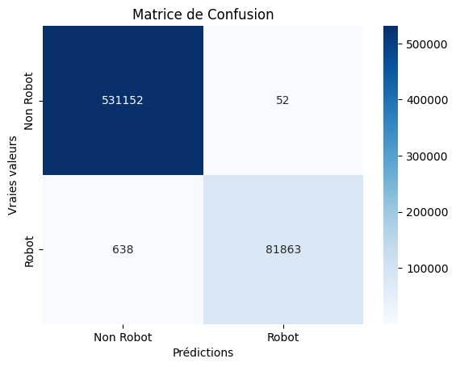

```python
rf_models =RandomForestClassifier()
# Entraîner le modèle en utilisant la pipeline
rf_models.fit(X_train, y_train)
# Prédire sur l'ensemble de test
y_rf = rf_models.predict(X_test)
# Afficher le rapport de classification
class_report = classification_report(y_test, y_rf )
print("Rapport de Classification :")
print(class_report)

# Calculez la matrice de confusion
conf_matrix_rf = confusion_matrix(y_test, y_rf)

# Affichez la matrice de confusion sous forme de heatmap
sns.heatmap(conf_matrix_rf, annot=True, fmt='d', cmap='Blues', xticklabels=['Non Robot', 'Robot'], yticklabels=['Non Robot', 'Robot'])
plt.xlabel('Prédictions')
plt.ylabel('Vraies valeurs')
plt.title('Matrice de Confusion')
plt.show()
```

Le `randomforest` sur la totalité de la donnée avec la colonne `bidder_id` a une forte précision (~ 100%). Elle performe ce pendant moins bien que la `regression logistic` implémentée dans les mêmes conditions. Encore une fois, on remarque l'influence de la colonné `bidder_id` qui améliore significativement la prédiction.

### RandomForest sans bidder_id sur toute les données

```python
# Créer un objet LabelEncoder
label_encoder = LabelEncoder()

categorical_features = ['auction', 'merchandise', 'device', 'country', 'ip', 'url']
numeric_features = ['time']

# Normaliser les time
scaler = StandardScaler()
data[numeric_features] = scaler.fit_transform(data[numeric_features])


# Appliquer Label Encoding aux variables catégorielles
for feature in categorical_features:
    data[feature] = label_encoder.fit_transform(data[feature])


X_train_, X_test_, y_train_, y_test_ = train_test_split(data.drop('outcome', axis=1), data['outcome'], test_size=0.2, random_state=42)
```

```
Rapport de Classification :
              precision    recall  f1-score   support

         0.0       0.97      0.99      0.98    531204
         1.0       0.95      0.79      0.86     82501

    accuracy                           0.97    613705
   macro avg       0.96      0.89      0.92    613705
weighted avg       0.97      0.97      0.96    613705
```

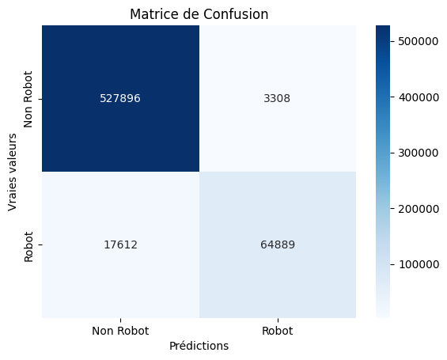

```python
rf_models =RandomForestClassifier()
# Entraîner le modèle en utilisant la pipeline
rf_models.fit(X_train_, y_train_)
# Prédire sur l'ensemble de test
y_rf_ = rf_models.predict(X_test_)
# Afficher le rapport de classification
class_report = classification_report(y_test_, y_rf_ )
print("Rapport de Classification :")
print(class_report)

# Calculez la matrice de confusion
conf_matrix_rf = confusion_matrix(y_test_, y_rf_)

# Affichez la matrice de confusion sous forme de heatmap
sns.heatmap(conf_matrix_rf, annot=True, fmt='d', cmap='Blues', xticklabels=['Non Robot', 'Robot'], yticklabels=['Non Robot', 'Robot'])
plt.xlabel('Prédictions')
plt.ylabel('Vraies valeurs')
plt.title('Matrice de Confusion')
plt.show()
```

Globalement le constat est le même que dans le cas de la regression logistique. Le retrait de la colonne `bidder_id` et l'utilisation de toute la base de données entraine une regression du `recall`. Cependant il est notable que dans le cas du random forest, on a un meileur recall que dans le cas de la regession logistique (79% contre 75%).

Nous passons à l'utilisation des données échantillonnées. Et comme dans le cas de la regression logistique, nous commençons par le modèle conservant `bidder_id`.

### RandomForest avec bidder_id sur l'échantillon

```python
# sous-échantillonage de la dataset avec bidder_id
rus = RandomUnderSampler(random_state=42)
X_resampled, y_resampled = rus.fit_resample(X_train, y_train)

rf_model =RandomForestClassifier()
```

```
Rapport de Classification :
              precision    recall  f1-score   support

         0.0       1.00      1.00      1.00    531204
         1.0       0.98      1.00      0.99     82501

    accuracy                           1.00    613705
   macro avg       0.99      1.00      0.99    613705
weighted avg       1.00      1.00      1.00    613705
```

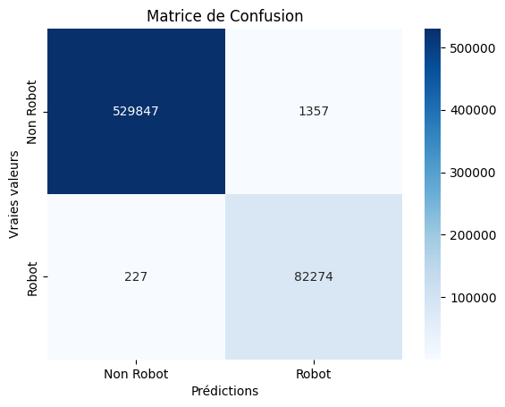

```python
# Entraîner le modèle en utilisant la pipeline
rf_model.fit(X_resampled, y_resampled)
# Prédire sur l'ensemble de test
y_rf = rf_model.predict(X_test)
# Afficher le rapport de classification
class_report = classification_report(y_test, y_rf )
print("Rapport de Classification :")
print(class_report)

# Calculez la matrice de confusion
conf_matrix_rf = confusion_matrix(y_test, y_rf)

# Affichez la matrice de confusion sous forme de heatmap
sns.heatmap(conf_matrix_rf, annot=True, fmt='d', cmap='Blues', xticklabels=['Non Robot', 'Robot'], yticklabels=['Non Robot', 'Robot'])
plt.xlabel('Prédictions')
plt.ylabel('Vraies valeurs')
plt.title('Matrice de Confusion')
plt.show()
```

Le résultats ici encore est très bon. La première conclusion est quand même que le random forest fonctionne moins bien qu'une regression logistique quand la colonne `bidder_id` est utilisée. Dans la dernière approche nous implémentons le modèle le plus pertinent dans notre cas.

### RandomForest sans bidder_id sur l'échantillon

```python
# sous-échantillonage de la dataset avec bidder_id
rus = RandomUnderSampler(random_state=42)
X_resampled_, y_resampled_ = rus.fit_resample(X_train_, y_train_)

rf_model_ =RandomForestClassifier()
```

```
Rapport de Classification :
              precision    recall  f1-score   support

         0.0       0.99      0.93      0.96    531204
         1.0       0.68      0.92      0.79     82501

    accuracy                           0.93    613705
   macro avg       0.84      0.93      0.87    613705
weighted avg       0.95      0.93      0.94    613705
```

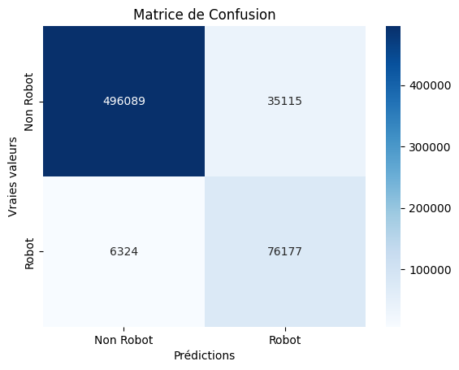

```python
# Entraîner le modèle en utilisant la pipeline
rf_model_.fit(X_resampled_, y_resampled_)
# Prédire sur l'ensemble de test
y_rf_ = rf_model_.predict(X_test_)
# Afficher le rapport de classification
class_report = classification_report(y_test_, y_rf_ )
print("Rapport de Classification :")
print(class_report)

# Calculez la matrice de confusion
conf_matrix_rf = confusion_matrix(y_test_, y_rf_)

# Affichez la matrice de confusion sous forme de heatmap
sns.heatmap(conf_matrix_rf, annot=True, fmt='d', cmap='Blues', xticklabels=['Non Robot', 'Robot'], yticklabels=['Non Robot', 'Robot'])
plt.xlabel('Prédictions')
plt.ylabel('Vraies valeurs')
plt.title('Matrice de Confusion')
plt.show()
```

Le modèle implémenté ci-dessus est celui su random forest sur les données échantillonnées et sans `bidder_id`. La justification de son importance reste la même que celle donnée dans le cas de la regression logistique. Les résultats obtenus sont nettement meilleurs que ceux observés dans le cas de la regression logistique sur les mêmes données. On a un recall de 92% contre les 90% obtenus plus haut. Sans la colonne `bidder_id`, le random forest performe donc bien mieux que la regression logistique. Enfin, encore une fois l'échantillonnage (rééquilibrage) améliore la prédiction des enchères émises par des robots en absence de `bidder_id`.

La configuration de la prédiction sans `bidder_id` et sur la donnée échantillonnée étant la plus pertinente, nous implémentons ci-dessous une cross validation dans le but d'améliorer les performances précédentes. Deux implémentations sont faites. Elles optimisent respectivement l'`accuracy` et le `recall`

### Cross Validation du RandomForest sans bidder_id sur l'échantillon

#### Optimisation de l'accuracy

```python
# Sous-échantillonnage de la dataset avec bidder_id
rus = RandomUnderSampler(random_state=42)
X_resampled_, y_resampled_ = rus.fit_resample(X_train_, y_train_)

# RandomForestClassifier avec prétraitement
rf_model = RandomForestClassifier()

# Définir la plage de valeurs pour les paramètres à rechercher
param_grid = {
    'n_estimators': [100, 150, 200],
    'max_depth': [None, 5, 8, 10],
    'min_samples_leaf' : [1, 2]
}

# Recherche de grille avec validation croisée
grid_search = GridSearchCV(estimator=rf_model, param_grid=param_grid, cv=6, scoring='accuracy', n_jobs=-1)

grid_search.fit(X_resampled_, y_resampled_)

# Afficher les meilleurs paramètres
print("Meilleurs paramètres :", grid_search.best_params_)
```

```
Meilleurs paramètres : {'max_depth': None, 'min_samples_leaf': 1, 'n_estimators': 200}
```

```
Précision sur les données de test: 0.9325082898135097
Rapport de Classification :
              precision    recall  f1-score   support

         0.0       0.99      0.93      0.96    531204
         1.0       0.68      0.93      0.79     82501

    accuracy                           0.93    613705
   macro avg       0.84      0.93      0.87    613705
weighted avg       0.95      0.93      0.94    613705
```

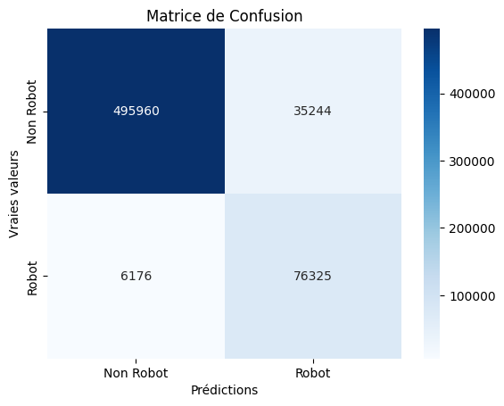

```python
# Évaluer la performance du modèle sur les données de test
recall_score = grid_search.best_estimator_.score(X_test_, y_test_)
print("Précision sur les données de test:", recall_score)

# Utiliser le meilleur modèle trouvé
best_rf_model = grid_search.best_estimator_

# Prédire sur l'ensemble de test
y_rf = best_rf_model.predict(X_test_)

# Afficher le rapport de classification
class_report_rf = classification_report(y_test_, y_rf)
print("Rapport de Classification :")
print(class_report_rf)

# Calculez la matrice de confusion
conf_matrix_rf = confusion_matrix(y_test_, y_rf)

# Affichez la matrice de confusion sous forme de heatmap
sns.heatmap(conf_matrix_rf, annot=True, fmt='d', cmap='Blues', xticklabels=['Non Robot', 'Robot'], yticklabels=['Non Robot', 'Robot'])
plt.xlabel('Prédictions')
plt.ylabel('Vraies valeurs')
plt.title('Matrice de Confusion')
plt.show()
```

#### Optimisation du Recall

```python
# Sous-échantillonnage de la dataset avec bidder_id
rus = RandomUnderSampler(random_state=42)
X_resampled_, y_resampled_ = rus.fit_resample(X_train_, y_train_)

# RandomForestClassifier avec prétraitement
rf_model = RandomForestClassifier()

# Définir la plage de valeurs pour les paramètres à rechercher
param_grid = {
    'n_estimators': [100, 150, 200],
    'max_depth': [None, 5, 8, 10],
    'min_samples_leaf' : [1, 2]
}

# Recherche de grille avec validation croisée
grid_search = GridSearchCV(estimator=rf_model, param_grid=param_grid, cv=6, scoring='recall', n_jobs=-1)

grid_search.fit(X_resampled_, y_resampled_)

# Afficher les meilleurs paramètres
print("Meilleurs paramètres :", grid_search.best_params_)
```

```
Meilleurs paramètres : {'max_depth': None, 'min_samples_leaf': 1, 'n_estimators': 150}
```

```
Précision sur les données de test: 0.9325555437873245
Rapport de Classification :
              precision    recall  f1-score   support

         0.0       0.99      0.93      0.96    531204
         1.0       0.68      0.92      0.79     82501

    accuracy                           0.93    613705
   macro avg       0.84      0.93      0.87    613705
weighted avg       0.95      0.93      0.94    613705
```

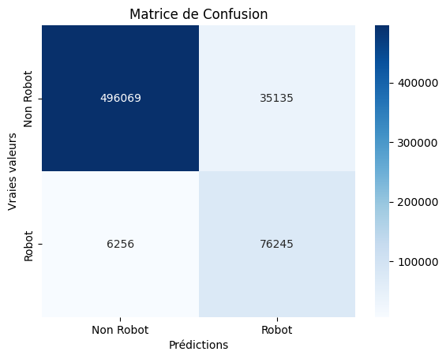

```python
# Évaluer la performance du modèle sur les données de test
recall_score = grid_search.best_estimator_.score(X_test_, y_test_)
print("Précision sur les données de test:", recall_score)

# Utiliser le meilleur modèle trouvé
best_rf_model = grid_search.best_estimator_

# Prédire sur l'ensemble de test
y_rf = best_rf_model.predict(X_test_)

# Afficher le rapport de classification
class_report_rf = classification_report(y_test_, y_rf)
print("Rapport de Classification :")
print(class_report_rf)

# Calculez la matrice de confusion
conf_matrix_rf = confusion_matrix(y_test_, y_rf)

# Affichez la matrice de confusion sous forme de heatmap
sns.heatmap(conf_matrix_rf, annot=True, fmt='d', cmap='Blues', xticklabels=['Non Robot', 'Robot'], yticklabels=['Non Robot', 'Robot'])
plt.xlabel('Prédictions')
plt.ylabel('Vraies valeurs')
plt.title('Matrice de Confusion')
plt.show()
```

## Gradient Boosting

**Cross Validation du Gradient Boosting sans bidder_id sur l'échantillon**

```python
pip install xgboost
```

```
  Using cached xgboost-2.0.3-py3-none-win_amd64.whl (99.8 MB)
```

```python
from xgboost import XGBClassifier
from sklearn.model_selection import GridSearchCV, StratifiedKFold
from sklearn.metrics import roc_auc_score, precision_score, recall_score, f1_score, confusion_matrix
```

Nous recherchons ici les meilleurs paramètres sur 4 variables dont notamment le nombre d'estimateurs (arbres) et la contribution de chaque arbre au modèle final.

```python
# Définir le modèle XGBoost
xgb_model = XGBClassifier(random_state=42)

# Définir la grille de paramètres pour la recherche par grille
param_grid = {
    'n_estimators': [100, 200],
    'max_depth': [None, 3,  10],
    'learning_rate': [0.01, 0.1],
    'gamma':  [0.1, 0.2]
}

# Utiliser StratifiedKFold pour gérer le déséquilibre des classes
cv = StratifiedKFold(n_splits=10)

# Recherche par grille avec validation croisée
grid = GridSearchCV(xgb_model, param_grid, cv=cv, scoring='recall', verbose=2)
grid.fit(X_resampled_, y_resampled_)

# Meilleurs paramètres et meilleur score
print("Meilleurs paramètres trouvés : ", grid.best_params_)
print("Meilleur score AUC trouvé : ", grid.best_score_)

# Prédictions
y_pred = grid.predict(X_test_)
y_pred_proba = grid.predict_proba(X_test_)[:, 1]
```

[output not shown]

[output cut: 188 more lines]

[output not shown]

```
Rapport de Classification :
              precision    recall  f1-score   support

         0.0       0.99      0.92      0.95    531204
         1.0       0.65      0.92      0.76     82501

    accuracy                           0.92    613705
   macro avg       0.82      0.92      0.86    613705
weighted avg       0.94      0.92      0.93    613705
```

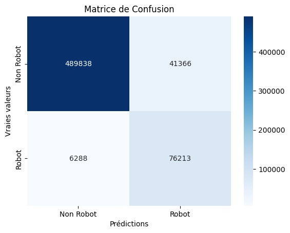

```python
# Prédictions
y_pred = grid.predict(X_test_)

# Afficher le rapport de classification
class_report = classification_report(y_test_, y_pred )
print("Rapport de Classification :")
print(class_report)

# Calculez la matrice de confusion
conf_matrix_rf = confusion_matrix(y_test_, y_pred)

# Affichez la matrice de confusion sous forme de heatmap
sns.heatmap(conf_matrix_rf, annot=True, fmt='d', cmap='Blues', xticklabels=['Non Robot', 'Robot'], yticklabels=['Non Robot', 'Robot'])
plt.xlabel('Prédictions')
plt.ylabel('Vraies valeurs')
plt.title('Matrice de Confusion')
plt.show()
```

Les meilleurs paramètres trouvés sont : {'gamma': 0.2, 'learning_rate': 0.1, 'max_depth': 10, 'n_estimators': 200}. Le recall atteint est de 92% sur ces paramètres. Il est bien mieux donc que la regression logistique mais performe moins bien (légèrement) que le random forest. De même, son `accuracy` de 92% le classe encore une fois entre les 2 premiers modèles.

## SVM

```python
SVM_model = SVC(probability=True, C=1.0, gamma=0.1, kernel='sigmoid')

SVM_model.fit(X_resampled_, y_resampled_)
y_svm_ = SVM_model.predict(X_test_)
# Afficher le rapport de classification
class_report = classification_report(y_test_, y_svm_ )
print("Rapport de Classification :")
print(class_report)

# Calculez la matrice de confusion
conf_matrix_rf = confusion_matrix(y_test_, y_svm_)

# Affichez la matrice de confusion sous forme de heatmap
sns.heatmap(conf_matrix_rf, annot=True, fmt='d', cmap='Blues', xticklabels=['Non Robot', 'Robot'], yticklabels=['Non Robot', 'Robot'])
plt.xlabel('Prédictions')
plt.ylabel('Vraies valeurs')
plt.title('Matrice de Confusion')
plt.show()
```

[output not shown]

## KNN

Nous explorons ici une recherce de meilleurs paramètres de knn pour la résolution de notre problème de classification.

```
Meilleurs paramètres : {'n_neighbors': 201}
Rapport de Classification :
              precision    recall  f1-score   support

         0.0       0.93      0.65      0.76    531204
         1.0       0.23      0.67      0.34     82501

    accuracy                           0.65    613705
   macro avg       0.58      0.66      0.55    613705
weighted avg       0.83      0.65      0.71    613705
```

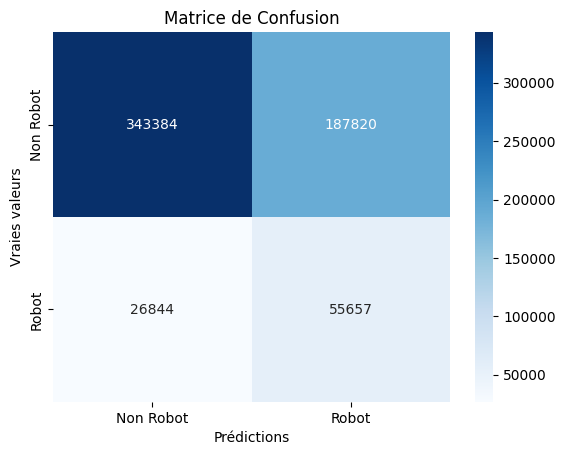

```python
# Définir la plage de valeurs pour n_neighbors
param_grid = {'n_neighbors': [81, 101, 201, 301, 301]}

# KNeighborsClassifier
knn_model_ = KNeighborsClassifier()

# Recherche de grille avec validation croisée
grid_search = GridSearchCV(knn_model_, param_grid, cv=5, scoring='recall')
grid_search.fit(X_resampled_, y_resampled_)

# Afficher les meilleurs paramètres
print("Meilleurs paramètres :", grid_search.best_params_)

# Utiliser le meilleur modèle trouvé
best_knn_model = grid_search.best_estimator_

# Prédire sur l'ensemble de test
y_knn_ = best_knn_model.predict(X_test_)

# Afficher le rapport de classification
class_report = classification_report(y_test_, y_knn_)
print("Rapport de Classification :")
print(class_report)

# Calculez la matrice de confusion
conf_matrix = confusion_matrix(y_test_, y_knn_)

# Affichez la matrice de confusion sous forme de heatmap
sns.heatmap(conf_matrix, annot=True, fmt='d', cmap='Blues', xticklabels=['Non Robot', 'Robot'], yticklabels=['Non Robot', 'Robot'])
plt.xlabel('Prédictions')
plt.ylabel('Vraies valeurs')
plt.title('Matrice de Confusion')
plt.show()
```

Les résultats obtenus ici sont moins encourageant. Il s'agit en effet du modèle qui performe le moins bien. Notamment avec une `accuracy` de 65% et un recall de 67%.

# **Conclusion**

En conclusion, ce travail pratique revêt une importance capitale, car il nous a permis d'implémenter plusieurs modèles de classification en utilisant divers paramètres. Ainsi, nous avons pu mettre en pratique les concepts enseignés au cours en les appliquant à une problématique concrète rencontrée dans le contexte professionnel.

À la suite de nos travaux, le modèle qui a démontré la meilleure performance est le random forest, affichant un taux de recall de 93%. En second lieu, nous retrouvons le gradient boosting avec un taux de recall de 92%, suivi de la régression logistique avec un taux de recall de 90%. Enfin, le KNN performe moins bien que les que les autres avec un recall de 67%.

Durant notre démarche, nous avons également rencontré plusieurs défis, tels que la compréhension de certaines variables comme time et la décision d'utiliser ou non la variable bidder_id, qui seule permet d'atteindre des niveaux de précision impressionnants. La principale difficulté réside dans le temps de compilation des différents modèles, dépassant même plusieurs heures.